# Supervised Classification

A classification problem can be defined as the induction, from a dataset $\cal D$, of a classification function $\psi$ that, given the attribute vector of an instance/example, returns a class ${c}$. A regression problem, on the other hand, returns an numeric value.

Dataset, $\cal D$, is typically composed of $n$ attributes and a class attribute $C$.

| $Att_1$ | … | Attn | C |
| --- | --- | --- | --- |
| $a_{11}$ | … | a1n | c1 |
| $a_{21}$ | … | a2n | c2 |
| … | … | … | … |
| $a_{m1}$ | … | amn | cm |

Columns are usually called attributes and there is class attribute, which can be numeric or discrete. When the class is numeric, it is a regression problem. With discrete values, we talk about binary (two values) classification or multi-label classification

## Regression

### Linear Regression

- This procedure fits a straight line to the data. The idea is that the independent variable x is something the experimenter controls and the dependent variable y is something that the experimenter measures. The line is used to predict the value of y for a known value of x. The variable x is the predictor variable and y the response variable.
- First proposed many years ago. But still very useful…

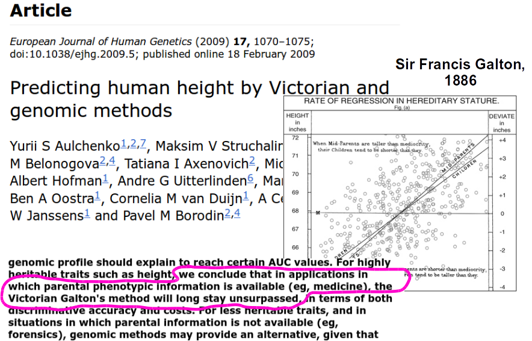

  Galton Data

- The equation takes the form $\hat{y}=b_0+b_1 * x$
- The method used to choose the values $b_0$ and $b_1$ is to minimize the sum of the squares of the residual errors.

## Regression: Galton Data

Not related to Software Engineering but …

```r
library(UsingR); data(galton)
```

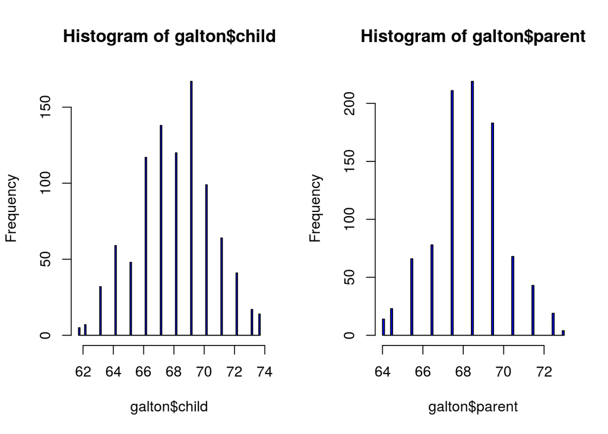

```r
par(mfrow=c(1,2))
hist(galton$child,col="blue",breaks=100)
hist(galton$parent,col="blue",breaks=100)
```

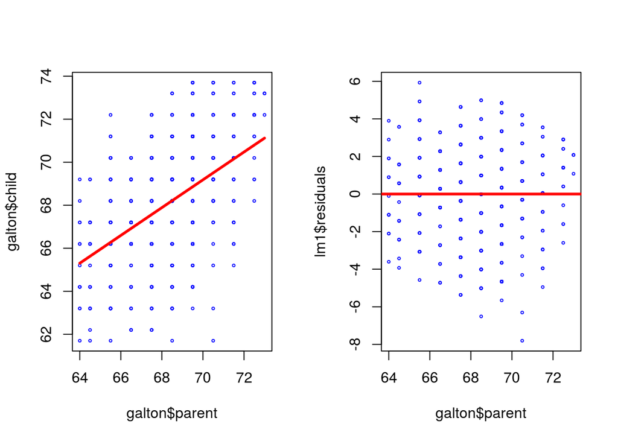

```r
plot(galton$parent,galton$child,pch=1,col="blue", cex=0.4)
lm1 <- lm(galton$child ~ galton$parent)
lines(galton$parent,lm1$fitted,col="red",lwd=3)
plot(galton$parent,lm1$residuals,col="blue",pch=1, cex=0.4)
abline(c(0,0),col="red",lwd=3)
```

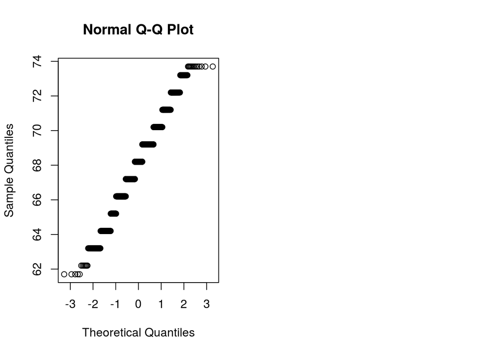

```r
qqnorm(galton$child)
```

## Linear Regression Diagnostics

- Several plots help to evaluate the suitability of the linear regression
  - *Residuals vs fitted*: The residuals should be randomly distributed around the horizontal line representing a residual error of zero; that is, there should not be a distinct trend in the distribution of points.
  - *Standard Q-Q plot*: residual errors are normally distributed
  - *Square root of the standardized residuals vs the fitted value*s: there should be no obvious trend.
  - *Leverage*: measures the importance of each point in determining the regression result. Smaller values means that removing the observation has little effect on the regression result.

## Linear regression

### Effort estimation

Fitting a linear model to log-log - the predictive power equation is $y= e^{b_0 + b_1 log(x)}$, ignoring the bias corrections - First, we are fitting the model to the whole dataset. But it is not the right way to do it, because of overfitting.

```r
library(foreign)
china <- read.arff("./datasets/china.arff")
china_size <- china$AFP
summary(china_size)
```

```
##    Min. 1st Qu.  Median    Mean 3rd Qu.    Max.
##     9.0   100.5   215.0   486.9   437.5 17520.0
```

```r
china_effort <- china$Effort
summary(china_effort)
```

```
##    Min. 1st Qu.  Median    Mean 3rd Qu.    Max.
##    26.0   703.5  1829.0  3921.0  3826.0 54620.0
```

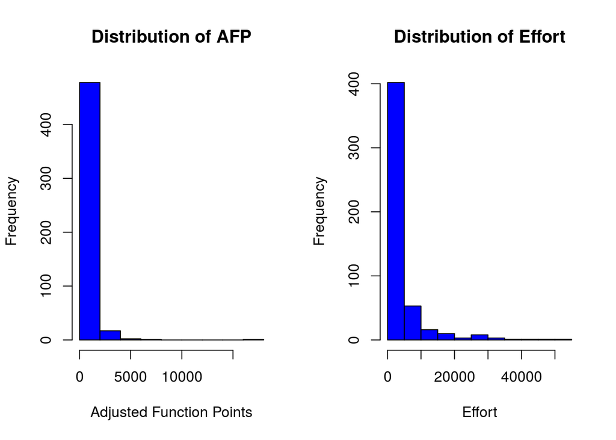

```r
par(mfrow=c(1,2))
hist(china_size, col="blue", xlab="Adjusted Function Points", main="Distribution of AFP")
hist(china_effort, col="blue",xlab="Effort", main="Distribution of Effort")
```

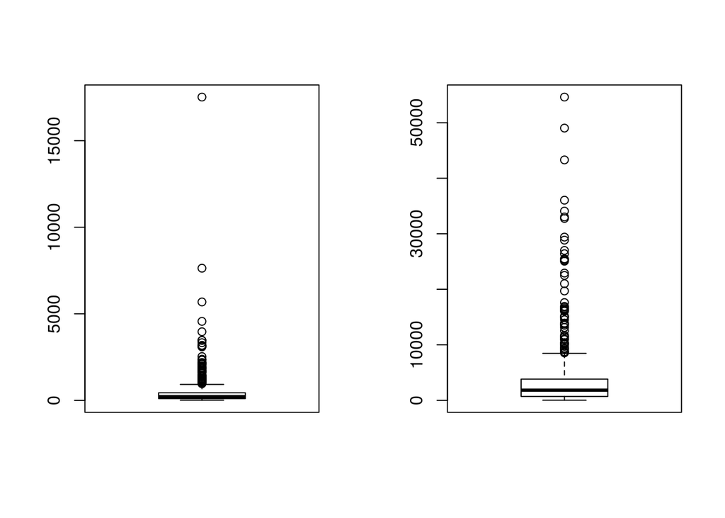

```r
boxplot(china_size)
boxplot(china_effort)
```

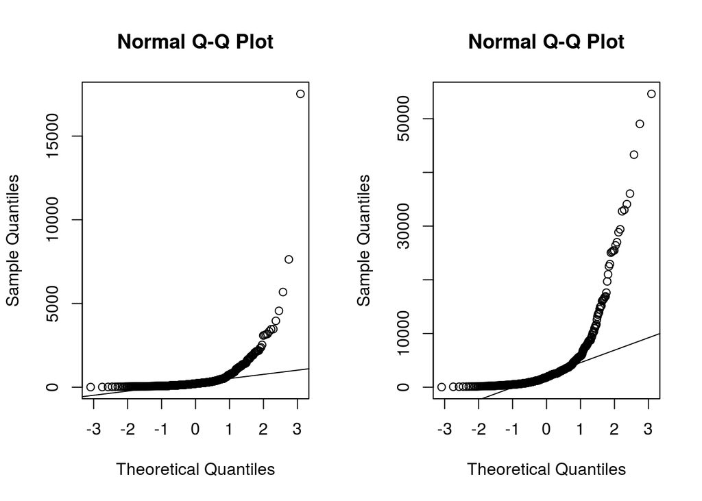

[figure not shown]

[figure not shown]

```r
qqnorm(china_size)
qqline(china_size)
qqnorm(china_effort)
qqline(china_effort)
```

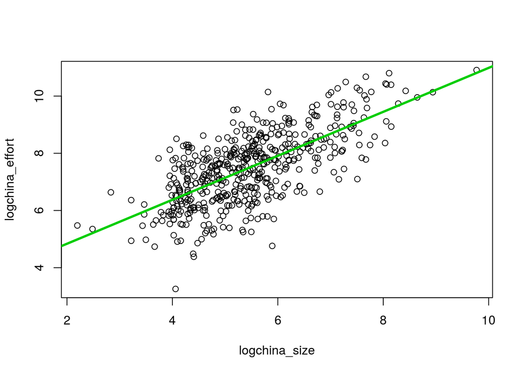

```r
linmodel_logchina <- lm(logchina_effort ~ logchina_size)
par(mfrow=c(1,1))
plot(logchina_size, logchina_effort)
abline(linmodel_logchina, lwd=3, col=3)
```

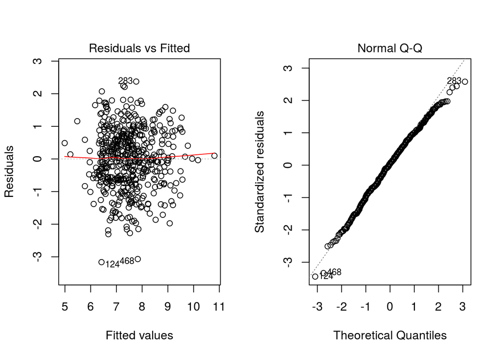

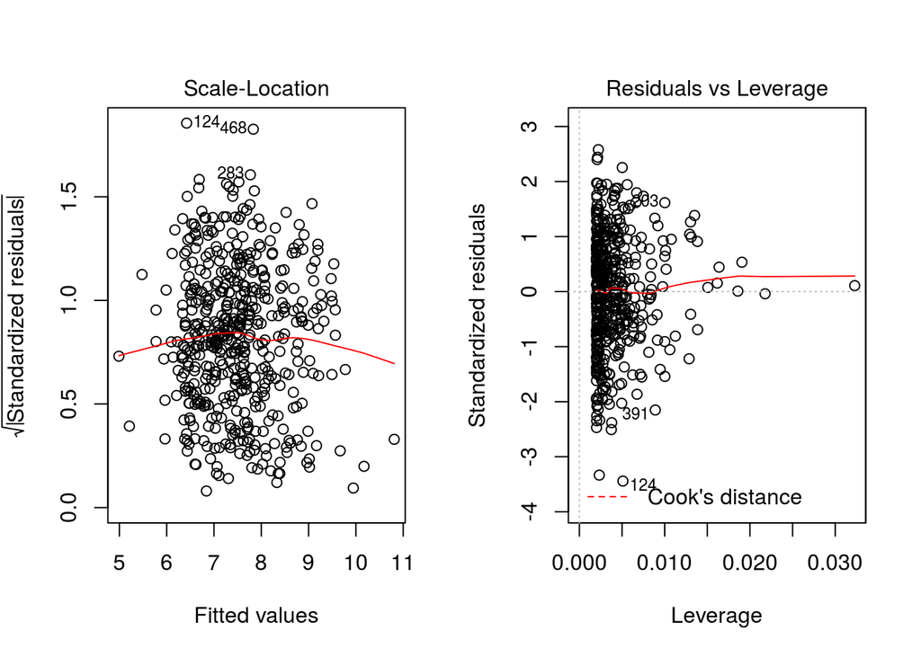

```r
par(mfrow=c(1,2))
plot(linmodel_logchina, ask = FALSE)
```

```r
linmodel_logchina
```

```
##
## Call:
## lm(formula = logchina_effort ~ logchina_size)
##
## Coefficients:
##   (Intercept)  logchina_size
##        3.3010         0.7685
```

## Supervised Classification

Here we will use defect prediction as ensample of several machine learning techniques.

> **No Free Lunch theorem** In the absence of any knowledge about the prediction problem, no model can be said to be uniformly better than any other

There are hundreds of packages to perform classification task in R, but many of those can be used throught ‘caret’ which helps with many of the data mining process task as described next.

### The caret package

The [caret (Classification And REgression Training) package](http://topepo.github.io/caret/) provides a unified interface for modeling and prediction with around 150 different models with tools for:

```
+ data splitting
+ pre-processing
+ feature selection
+ model tuning using resampling
+ variable importance estimation, etc.
```

Website: http://caret.r-forge.r-project.org

JSS Paper: www.jstatsoft.org/v28/i05/paper

Book: [Applied Predictive Modeling](http://AppliedPredictiveModeling.com/)

### Defect Prediction as a running example

We will show the use of different classification techniques in the problem of defect prediction.

Different datasets are composed of classical metrics (Halstead or McCabe metrics) based on counts of operators/operands and like or object-oriented metrics (e.g. Chidamber and Kemerer) and the class attribute indicating whether the module or class was defective.

For example, using one of the NASA datasets used extensively in defect prediction:

```r
library(caret)
library(foreign)

kc1 <- read.arff("./datasets/defectPred/D1/KC1.arff")
str(kc1)
```

```
## 'data.frame':    2096 obs. of  22 variables:
##  $ LOC_BLANK            : num  0 0 0 0 2 0 0 0 0 2 ...
##  $ BRANCH_COUNT         : num  1 1 1 1 1 1 1 1 1 1 ...
##  $ LOC_CODE_AND_COMMENT : num  0 0 0 0 0 0 0 0 0 0 ...
##  $ LOC_COMMENTS         : num  0 0 0 0 0 0 0 0 0 0 ...
##  $ CYCLOMATIC_COMPLEXITY: num  1 1 1 1 1 1 1 1 1 1 ...
##  $ DESIGN_COMPLEXITY    : num  1 1 1 1 1 1 1 1 1 1 ...
##  $ ESSENTIAL_COMPLEXITY : num  1 1 1 1 1 1 1 1 1 1 ...
##  $ LOC_EXECUTABLE       : num  3 1 1 1 8 3 1 1 1 9 ...
##  $ HALSTEAD_CONTENT     : num  11.6 0 0 0 18 ...
##  $ HALSTEAD_DIFFICULTY  : num  2.67 0 0 0 3.5 2.67 0 0 0 3.75 ...
##  $ HALSTEAD_EFFORT      : num  82.3 0 0 0 220.9 ...
##  $ HALSTEAD_ERROR_EST   : num  0.01 0 0 0 0.02 0.01 0 0 0 0.04 ...
##  $ HALSTEAD_LENGTH      : num  11 1 1 1 19 11 1 1 1 29 ...
##  $ HALSTEAD_LEVEL       : num  0.38 0 0 0 0.29 0.38 0 0 0 0.27 ...
##  $ HALSTEAD_PROG_TIME   : num  4.57 0 0 0 12.27 ...
##  $ HALSTEAD_VOLUME      : num  30.9 0 0 0 63.1 ...
##  $ NUM_OPERANDS         : num  4 0 0 0 7 4 0 0 0 10 ...
##  $ NUM_OPERATORS        : num  7 1 1 1 12 7 1 1 1 19 ...
##  $ NUM_UNIQUE_OPERANDS  : num  3 0 0 0 5 3 0 0 0 8 ...
##  $ NUM_UNIQUE_OPERATORS : num  4 1 1 1 5 4 1 1 1 6 ...
##  $ LOC_TOTAL            : num  5 3 3 3 12 5 3 3 3 13 ...
##  $ Defective            : Factor w/ 2 levels "N","Y": 1 1 1 1 1 1 1 1 1 1 ...
```

Then we need to divide the data into training and testing.

```r
# Split data into training and test datasets
set.seed(1)
inTrain <- createDataPartition(y=kc1$Defective,p=.75,list=FALSE)
kc1.train <- kc1[inTrain,]
kc1.test <- kc1[-inTrain,]
```

Another approach to dividing the data:

```r
# Split data into training and test datasets

set.seed(1)
ind <- sample(2, nrow(kc1), replace = TRUE, prob = c(0.75, 0.25))
kc1.train <- kc1[ind==1, ]
kc1.test <- kc1[ind==2, ]
```

## Linear Discriminant Analysis (LDA)

One classical approach to classification is Linear Discriminant Analysis (LDA). And the basic all would be as follows.

```r
ldaModel <- train (Defective ~ ., data=kc1.train, method="lda", preProc=c("center","scale"))

ldaModel
```

```
## Linear Discriminant Analysis
##
## 1573 samples
##   21 predictors
##    2 classes: 'N', 'Y'
##
## Pre-processing: centered (21), scaled (21)
## Resampling: Bootstrapped (25 reps)
## Summary of sample sizes: 1573, 1573, 1573, 1573, 1573, 1573, ...
## Resampling results:
##
##   Accuracy   Kappa
##   0.8546253  0.2864818
##
##
```

We can observe that we are training our model using `Defective ~ .` as a formula were ’Defective is the class variable separed by `~` and the ´.´ means the rest of the variables. Also, we are using a filter for the training data to (preProc) to center and scale.

Also, as stated in the documentation about the `train` method : > http://topepo.github.io/caret/training.html

```r
ctrl <- trainControl(method = "repeatedcv",repeats=3)
ldaModel <- train (Defective ~ ., data=kc1.train, method="lda", trControl=ctrl, preProc=c("center","scale"))

ldaModel
```

```
## Linear Discriminant Analysis
##
## 1573 samples
##   21 predictors
##    2 classes: 'N', 'Y'
##
## Pre-processing: centered (21), scaled (21)
## Resampling: Cross-Validated (10 fold, repeated 3 times)
## Summary of sample sizes: 1416, 1416, 1415, 1416, 1415, 1416, ...
## Resampling results:
##
##   Accuracy   Kappa
##   0.8544282  0.2876275
##
##
```

Instead of accuracy we can activate other metrics using `summaryFunction=twoClassSummary` such as `ROC`, `sensitivity` and `specificity`. To do so, we also need to speficy `classProbs=TRUE`.

```r
ctrl <- trainControl(method = "repeatedcv",repeats=3, classProbs=TRUE,
summaryFunction=twoClassSummary)
ldaModel3xcv10 <- train (Defective ~ ., data=kc1.train, method="lda", trControl=ctrl, preProc=c("center","scale"))

ldaModel3xcv10
```

```
## Linear Discriminant Analysis
##
## 1573 samples
##   21 predictors
##    2 classes: 'N', 'Y'
##
## Pre-processing: centered (21), scaled (21)
## Resampling: Cross-Validated (10 fold, repeated 3 times)
## Summary of sample sizes: 1416, 1416, 1416, 1416, 1416, 1415, ...
## Resampling results:
##
##   ROC        Sens       Spec
##   0.7890678  0.9621193  0.2600556
##
##
```

```r
plsFit3x10cv <- train (Defective ~ ., data=kc1.train, method="pls", trControl=ctrl, metric="ROC", preProc=c("center","scale"))

plsFit3x10cv
```

```
## Partial Least Squares
##
## 1573 samples
##   21 predictors
##    2 classes: 'N', 'Y'
##
## Pre-processing: centered (21), scaled (21)
## Resampling: Cross-Validated (10 fold, repeated 3 times)
## Summary of sample sizes: 1415, 1416, 1415, 1416, 1415, 1417, ...
## Resampling results across tuning parameters:
##
##   ncomp  ROC        Sens       Spec
##   1      0.7895201  0.9811859  0.08733333
##   2      0.7947289  0.9856953  0.12844444
##   3      0.7923594  0.9829403  0.14216667
##
## ROC was used to select the optimal model using  the largest value.
## The final value used for the model was ncomp = 2.
```

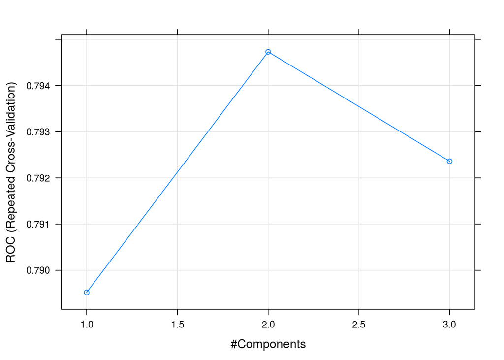

```r
plot(plsFit3x10cv)
```

The parameter `tuneLength` allow us to specify the number values per parameter to consider.

```r
plsFit3x10cv <- train (Defective ~ ., data=kc1.train, method="pls", trControl=ctrl, metric="ROC", tuneLength=5, preProc=c("center","scale"))

plsFit3x10cv
```

```
## Partial Least Squares
##
## 1573 samples
##   21 predictors
##    2 classes: 'N', 'Y'
##
## Pre-processing: centered (21), scaled (21)
## Resampling: Cross-Validated (10 fold, repeated 3 times)
## Summary of sample sizes: 1417, 1416, 1415, 1415, 1416, 1416, ...
## Resampling results across tuning parameters:
##
##   ncomp  ROC        Sens       Spec
##   1      0.7884563  0.9811859  0.08766667
##   2      0.7948362  0.9854542  0.12861111
##   3      0.7923943  0.9821922  0.15061111
##   4      0.7913298  0.9847004  0.16150000
##   5      0.7909973  0.9847042  0.16400000
##
## ROC was used to select the optimal model using  the largest value.
## The final value used for the model was ncomp = 2.
```

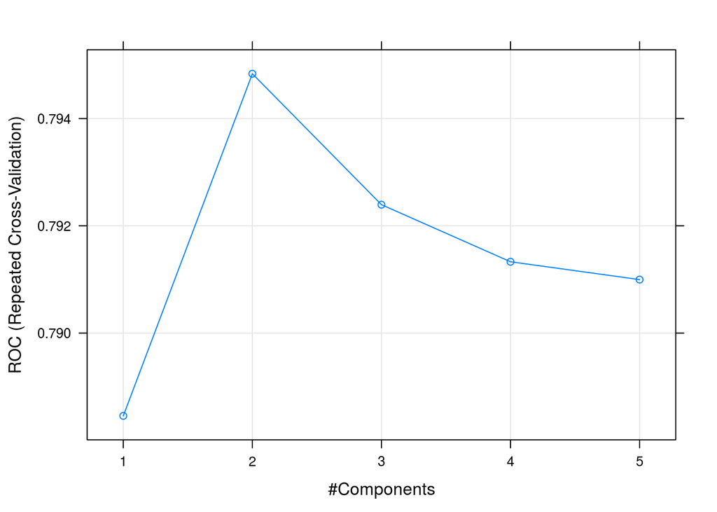

```r
plot(plsFit3x10cv)
```

Finally to predict new cases, `caret` will use the best classfier obtained for prediction.

```r
plsProbs <- predict(plsFit3x10cv, newdata = kc1.test, type = "prob")
```

```r
plsClasses <- predict(plsFit3x10cv, newdata = kc1.test, type = "raw")
confusionMatrix(data=plsClasses,kc1.test$Defective)
```

```
## Confusion Matrix and Statistics
##
##           Reference
## Prediction   N   Y
##          N 439  69
##          Y   3  12
##
##                Accuracy : 0.8623
##                  95% CI : (0.8298, 0.8907)
##     No Information Rate : 0.8451
##     P-Value [Acc > NIR] : 0.1519
##
##                   Kappa : 0.2119
##  Mcnemar's Test P-Value : 1.855e-14
##
##             Sensitivity : 0.9932
##             Specificity : 0.1481
##          Pos Pred Value : 0.8642
##          Neg Pred Value : 0.8000
##              Prevalence : 0.8451
##          Detection Rate : 0.8394
##    Detection Prevalence : 0.9713
##       Balanced Accuracy : 0.5707
##
##        'Positive' Class : N
##
```

### Predicting the number of defects (numerical class)

From the Bug Predictiono Repository http://bug.inf.usi.ch/download.php

Some datasets contain CK and other 11 object oriented metrics for the last version of the system plus categorized (with severity and priority) post-release defects. Using such dataset:

```r
jdt <- read.csv("./datasets/defectPred/BPD/single-version-ck-oo-EclipseJDTCore.csv", sep=";")

# We just use the number of bugs, so we removed others
jdt$classname <- NULL
jdt$nonTrivialBugs <- NULL
jdt$majorBugs <- NULL
jdt$minorBugs <- NULL
jdt$criticalBugs <- NULL
jdt$highPriorityBugs <- NULL
jdt$X <- NULL

# Caret
library(caret)

# Split data into training and test datasets
set.seed(1)
inTrain <- createDataPartition(y=jdt$bugs,p=.8,list=FALSE)
jdt.train <- jdt[inTrain,]
jdt.test <- jdt[-inTrain,]
```

```r
ctrl <- trainControl(method = "repeatedcv",repeats=3)
glmModel <- train (bugs ~ ., data=jdt.train, method="glm", trControl=ctrl, preProc=c("center","scale"))
glmModel
```

```
## Generalized Linear Model
##
## 798 samples
##  17 predictors
##
## Pre-processing: centered (17), scaled (17)
## Resampling: Cross-Validated (10 fold, repeated 3 times)
## Summary of sample sizes: 718, 718, 718, 718, 719, 718, ...
## Resampling results:
##
##   RMSE       Rsquared
##   0.8411011  0.3855316
##
##
```

Others such as Elasticnet:

```r
glmnetModel <- train (bugs ~ ., data=jdt.train, method="glmnet", trControl=ctrl, preProc=c("center","scale"))
glmnetModel
```

```
## glmnet
##
## 798 samples
##  17 predictors
##
## Pre-processing: centered (17), scaled (17)
## Resampling: Cross-Validated (10 fold, repeated 3 times)
## Summary of sample sizes: 718, 718, 718, 718, 718, 718, ...
## Resampling results across tuning parameters:
##
##   alpha  lambda       RMSE       Rsquared
##   0.10   0.001202348  0.8127568  0.3411090
##   0.10   0.012023480  0.8183111  0.3344713
##   0.10   0.120234797  0.8077544  0.3396316
##   0.55   0.001202348  0.8119513  0.3412175
##   0.55   0.012023480  0.8227484  0.3268770
##   0.55   0.120234797  0.8117291  0.3473930
##   1.00   0.001202348  0.8116078  0.3407650
##   1.00   0.012023480  0.8189354  0.3309040
##   1.00   0.120234797  0.8167381  0.3445179
##
## RMSE was used to select the optimal model using  the smallest value.
## The final values used for the model were alpha = 0.1 and lambda
##  = 0.1202348.
```

# Binary Logistic Regression (BLR)

```r
jdt <- read.csv("./datasets/defectPred/BPD/single-version-ck-oo-EclipseJDTCore.csv", sep=";")

# Caret
library(caret)

# Convert the response variable into a boolean variable (0/1)
jdt$bugs[jdt$bugs>=1]<-1

cbo <- jdt$cbo
bugs <- jdt$bugs

# Split data into training and test datasets
jdt2 = data.frame(cbo, bugs)
inTrain <- createDataPartition(y=jdt2$bugs,p=.8,list=FALSE)
jdtTrain <- jdt2[inTrain,]
jdtTest <- jdt2[-inTrain,]
```

BLR models fault-proneness are as follows

$$fp(X) = \frac{e^{logit()}}{1 + e^{logit(X)}}$$

where the simplest form for logit is:

$logit(X) = c_{0} + c_{1}X$

```r
# logit regression
# glmLogit <- train (bugs ~ ., data=jdt.train, method="glm", family=binomial(link = logit))

glmLogit <- glm (bugs ~ ., data=jdtTrain, family=binomial(link = logit))
summary(glmLogit)
```

```
##
## Call:
## glm(formula = bugs ~ ., family = binomial(link = logit), data = jdtTrain)
##
## Deviance Residuals:
##     Min       1Q   Median       3Q      Max
## -3.5734  -0.6125  -0.5378  -0.4968   2.0992
##
## Coefficients:
##              Estimate Std. Error z value Pr(>|z|)
## (Intercept) -2.086378   0.134620 -15.498  < 2e-16 ***
## cbo          0.056462   0.007045   8.014 1.11e-15 ***
## ---
## Signif. codes:  0 '***' 0.001 '**' 0.01 '*' 0.05 '.' 0.1 ' ' 1
##
## (Dispersion parameter for binomial family taken to be 1)
##
##     Null deviance: 831.84  on 797  degrees of freedom
## Residual deviance: 725.93  on 796  degrees of freedom
## AIC: 729.93
##
## Number of Fisher Scoring iterations: 5
```

Predict a single point:

```r
newData = data.frame(cbo = 3)
predict(glmLogit, newData, type = "response")
```

```
##         1
## 0.1281974
```

Draw the results, modified from: http://www.shizukalab.com/toolkits/plotting-logistic-regression-in-r

```r
results <- predict(glmLogit, jdtTest, type = "response")

range(jdtTrain$cbo)
```

```
## [1]   0 156
```

```r
range(results)
```

```
## [1] 0.1104278 0.9840854
```

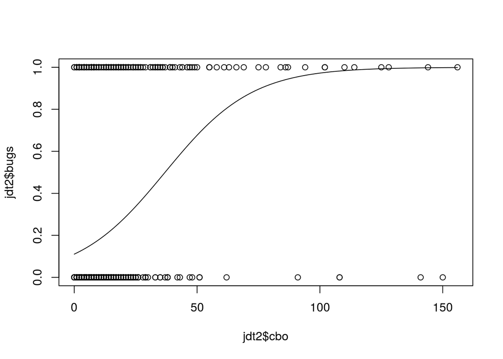

```r
plot(jdt2$cbo,jdt2$bugs)
curve(predict(glmLogit, data.frame(cbo=x), type = "response"),add=TRUE)
```

```r
# points(jdtTrain$cbo,fitted(glmLogit))
```

Another type of graph:

```r
library(popbio)
```

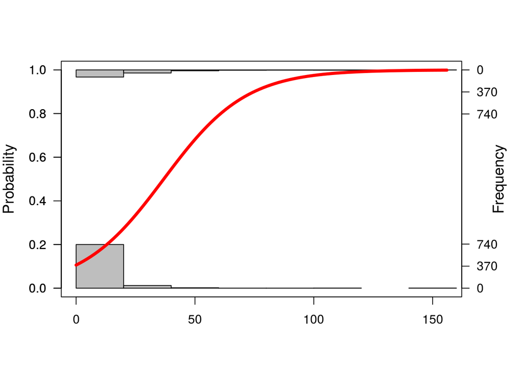

```r
logi.hist.plot(jdt2$cbo,jdt2$bugs,boxp=FALSE,type="hist",col="gray")
```

## Classification Trees

There are several packages for inducing classification trees, for example with the [party package](https://cran.r-project.org/web/packages/party/index.html) (recursive partitioning):

```r
# Build a decision tree
library(party)

kc2 <- read.arff("./datasets/defectPred/D1/MC1.arff")
str(kc2)
```

```
## 'data.frame':    9277 obs. of  39 variables:
##  $ LOC_BLANK                      : num  0 0 0 0 0 0 0 0 0 0 ...
##  $ BRANCH_COUNT                   : num  1 1 1 1 1 1 1 1 1 1 ...
##  $ CALL_PAIRS                     : num  0 0 0 0 0 0 0 0 0 0 ...
##  $ LOC_CODE_AND_COMMENT           : num  0 0 0 0 0 0 0 0 0 0 ...
##  $ LOC_COMMENTS                   : num  0 0 0 0 0 0 0 0 0 0 ...
##  $ CONDITION_COUNT                : num  0 0 0 0 0 0 0 0 0 0 ...
##  $ CYCLOMATIC_COMPLEXITY          : num  1 1 1 1 1 1 1 1 1 1 ...
##  $ CYCLOMATIC_DENSITY             : num  1 1 1 1 1 1 1 1 1 1 ...
##  $ DECISION_COUNT                 : num  0 0 0 0 0 0 0 0 0 0 ...
##  $ DESIGN_COMPLEXITY              : num  1 1 1 1 1 1 1 1 1 1 ...
##  $ DESIGN_DENSITY                 : num  1 1 1 1 1 1 1 1 1 1 ...
##  $ EDGE_COUNT                     : num  1 1 1 1 1 1 1 1 1 1 ...
##  $ ESSENTIAL_COMPLEXITY           : num  1 1 1 1 1 1 1 1 1 1 ...
##  $ ESSENTIAL_DENSITY              : num  0 0 0 0 0 0 0 0 0 0 ...
```

[output cut: 25 more lines]

```r
set.seed(1)
inTrain <- createDataPartition(y=kc2$Defective,p=.60,list=FALSE)
kc2.train <- kc2[inTrain,]
kc2.test <- kc2[-inTrain,]

kc2.formula <- kc2$Defective ~ .
kc2.ctree <- ctree(kc2.formula, data = kc2.train)

# predict on test data
pred <- predict(kc2.ctree, newdata = kc2.test)
# check prediction result
table(pred, kc2.test$Defective)
```

```
##
## pred    N    Y
##    N 3683   27
##    Y    0    0
```

[figure not shown]

```r
plot(kc2.ctree)
```

Using the C50, there are two ways, specifying train and testing

```r
library(C50)
c50t <- C5.0(kc1.train[,-ncol(kc1.train)], kc1.train[,ncol(kc1.train)])
summary(c50t)
```

```
##
## Call:
## C5.0.default(x = kc1.train[, -ncol(kc1.train)], y =
##  kc1.train[, ncol(kc1.train)])
##
##
## C5.0 [Release 2.07 GPL Edition]      Fri Dec  2 11:55:18 2016
## -------------------------------
##
## Class specified by attribute `outcome'
##
## Read 1573 cases (22 attributes) from undefined.data
##
## Decision tree:
##
## LOC_EXECUTABLE <= 4: N (745/22)
## LOC_EXECUTABLE > 4:
## :...HALSTEAD_ERROR_EST <= 0.36: N (734/169)
##     HALSTEAD_ERROR_EST > 0.36:
##     :...DESIGN_COMPLEXITY > 19: N (6)
##         DESIGN_COMPLEXITY <= 19:
##         :...LOC_CODE_AND_COMMENT <= 1: Y (71/22)
##             LOC_CODE_AND_COMMENT > 1: N (17/4)
##
##
## Evaluation on training data (1573 cases):
##
##      Decision Tree
##    ----------------
##    Size      Errors
##
##       5  217(13.8%)   <<
##
##
##     (a)   (b)    <-classified as
##    ----  ----
##    1307    22    (a): class N
##     195    49    (b): class Y
##
##
##  Attribute usage:
##
##  100.00% LOC_EXECUTABLE
##   52.64% HALSTEAD_ERROR_EST
##    5.98% DESIGN_COMPLEXITY
##    5.59% LOC_CODE_AND_COMMENT
##
##
## Time: 0.0 secs
```

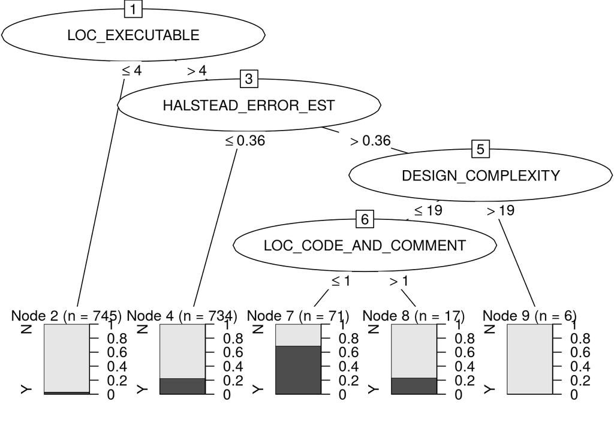

```r
plot(c50t)
```

```r
c50tPred <- predict(c50t, kc1.train)
table(c50tPred, kc1.train$Defective)
```

```
##
## c50tPred    N    Y
##        N 1307  195
##        Y   22   49
```

or using the formula approach:

```r
# Using the formula notation
c50t2 <- C5.0(Defective ~ ., kc1.train)
c50tPred2 <- predict(c50t2, kc1.train)
table(c50tPred2, kc1.train$Defective)
```

```
##
## c50tPred2    N    Y
##         N 1307  195
##         Y   22   49
```

Using the [‘rpart’ package](https://cran.r-project.org/web/packages/rpart/index.html)

[figure not shown]

```r
# Using the 'rpart' package
library(rpart)
kc1.rpart <- rpart(Defective ~ ., data=kc1.train)
plot(kc1.rpart)
```

```r
library(rpart.plot)
#asRules(kc1.rpart)
#fancyRpartPlot(kc1.rpart)
```

## Rules

C5 Rules

```r
library(C50)
c50r <- C5.0(kc1.train[,-ncol(kc1.train)], kc1.train[,ncol(kc1.train)], rules = TRUE)
summary(c50r)
```

```
##
## Call:
## C5.0.default(x = kc1.train[, -ncol(kc1.train)], y =
##  kc1.train[, ncol(kc1.train)], rules = TRUE)
##
##
## C5.0 [Release 2.07 GPL Edition]      Fri Dec  2 11:55:19 2016
## -------------------------------
##
## Class specified by attribute `outcome'
##
## Read 1573 cases (22 attributes) from undefined.data
##
## Rules:
##
## Rule 1: (1479/191, lift 1.0)
##  HALSTEAD_ERROR_EST <= 0.36
##  ->  class N  [0.870]
##
## Rule 2: (94/41, lift 3.6)
##  HALSTEAD_ERROR_EST > 0.36
##  ->  class Y  [0.563]
##
## Default class: N
##
##
## Evaluation on training data (1573 cases):
##
##          Rules
##    ----------------
##      No      Errors
##
##       2  232(14.7%)   <<
##
##
##     (a)   (b)    <-classified as
##    ----  ----
##    1288    41    (a): class N
##     191    53    (b): class Y
##
##
##  Attribute usage:
##
##  100.00% HALSTEAD_ERROR_EST
##
##
## Time: 0.0 secs
```

```r
c50rPred <- predict(c50r, kc1.train)
table(c50rPred, kc1.train$Defective)
```

```
##
## c50rPred    N    Y
##        N 1288  191
##        Y   41   53
```

## Distanced-based Methods

IB1 and IB-k

```r
library(class)

ind <- sample(2, nrow(iris), replace=T, prob=c(0.7, 0.3))
kc1.train <- kc1[ind==1, ]
kc1.test <- kc1[ind==2, ]

m1 <- knn(train=kc1.train[,-22], test=kc1.test[,-22], cl=kc1.train[,22], k=3)

table(kc1.test[,22],m1)
```

```
##    m1
##       N   Y
##   N 455  24
##   Y  64  15
```

## Probabilistic Methods

### Naive Bayes

Using the `klaR` package with `caret`:

```r
library(caret)
library(klaR)
model <- NaiveBayes(Defective ~ ., data = kc1.train)
predictions <- predict(model, kc1.test[,-22])
confusionMatrix(predictions$class, kc1.test$Defective)
```

```
## Confusion Matrix and Statistics
##
##           Reference
## Prediction   N   Y
##          N 442  53
##          Y  37  26
##
##                Accuracy : 0.8387
##                  95% CI : (0.8055, 0.8683)
##     No Information Rate : 0.8584
##     P-Value [Acc > NIR] : 0.9168
##
##                   Kappa : 0.2751
##  Mcnemar's Test P-Value : 0.1138
##
##             Sensitivity : 0.9228
##             Specificity : 0.3291
##          Pos Pred Value : 0.8929
##          Neg Pred Value : 0.4127
##              Prevalence : 0.8584
##          Detection Rate : 0.7921
##    Detection Prevalence : 0.8871
##       Balanced Accuracy : 0.6259
##
##        'Positive' Class : N
##
```

Using the `e1071` package:

```r
library (e1071)
n1 <-naiveBayes(kc1.train$Defective ~ ., data=kc1.train)

# Show first 3 results using 'class'
head(predict(n1,kc1.test, type = c("class")),3) # class by default
```

```
## [1] N N N
## Levels: N Y
```

```r
# Show first 3 results using 'raw'
head(predict(n1,kc1.test, type = c("raw")),3)
```

```
##      N            Y
## [1,] 1 2.401260e-09
## [2,] 1 5.756795e-09
## [3,] 1 5.756795e-09
```

### Bayesian Networks

To Do